# Introduction to Statistical Learning - Chapter 7

## Question 10

1. Split the data and perform forward selection.

```r
library(ISLR)
set.seed(1)
train = sample(1:nrow(College), nrow(College)/2)
test = -train
library(leaps)
reg.fwd = regsubsets(Outstate~., College[train,], nvmax=17, method = 'forward')
reg.fwd_summary = summary(reg.fwd)
reg.fwd_summary
```

```
## Subset selection object
## Call: regsubsets.formula(Outstate ~ ., College[train, ], nvmax = 17,
##     method = "forward")
## 17 Variables  (and intercept)
##             Forced in Forced out
## PrivateYes      FALSE      FALSE
## Apps            FALSE      FALSE
## Accept          FALSE      FALSE
## Enroll          FALSE      FALSE
## Top10perc       FALSE      FALSE
## Top25perc       FALSE      FALSE
## F.Undergrad     FALSE      FALSE
## P.Undergrad     FALSE      FALSE
## Room.Board      FALSE      FALSE
## Books           FALSE      FALSE
## Personal        FALSE      FALSE
## PhD             FALSE      FALSE
## Terminal        FALSE      FALSE
## S.F.Ratio       FALSE      FALSE
## perc.alumni     FALSE      FALSE
## Expend          FALSE      FALSE
## Grad.Rate       FALSE      FALSE
## 1 subsets of each size up to 17
## Selection Algorithm: forward
##           PrivateYes Apps Accept Enroll Top10perc Top25perc F.Undergrad
## 1  ( 1 )  " "        " "  " "    " "    " "       " "       " "
## 2  ( 1 )  "*"        " "  " "    " "    " "       " "       " "
## 3  ( 1 )  "*"        " "  " "    " "    " "       " "       " "
## 4  ( 1 )  "*"        " "  " "    " "    " "       " "       " "
## 5  ( 1 )  "*"        " "  " "    " "    " "       " "       " "
## 6  ( 1 )  "*"        " "  " "    " "    " "       " "       " "
## 7  ( 1 )  "*"        " "  " "    " "    " "       " "       " "
## 8  ( 1 )  "*"        " "  " "    " "    " "       " "       " "
## 9  ( 1 )  "*"        " "  "*"    " "    " "       " "       " "
## 10  ( 1 ) "*"        "*"  "*"    " "    " "       " "       " "
## 11  ( 1 ) "*"        "*"  "*"    " "    " "       " "       "*"
## 12  ( 1 ) "*"        "*"  "*"    " "    " "       " "       "*"
## 13  ( 1 ) "*"        "*"  "*"    " "    "*"       " "       "*"
## 14  ( 1 ) "*"        "*"  "*"    " "    "*"       " "       "*"
## 15  ( 1 ) "*"        "*"  "*"    " "    "*"       "*"       "*"
```

[output cut: 23 more lines]

```
## 3  ( 1 )  " "         "*"    " "
## 4  ( 1 )  "*"         "*"    " "
## 5  ( 1 )  "*"         "*"    " "
## 6  ( 1 )  "*"         "*"    "*"
## 7  ( 1 )  "*"         "*"    "*"
## 8  ( 1 )  "*"         "*"    "*"
## 9  ( 1 )  "*"         "*"    "*"
## 10  ( 1 ) "*"         "*"    "*"
## 11  ( 1 ) "*"         "*"    "*"
## 12  ( 1 ) "*"         "*"    "*"
## 13  ( 1 ) "*"         "*"    "*"
## 14  ( 1 ) "*"         "*"    "*"
## 15  ( 1 ) "*"         "*"    "*"
## 16  ( 1 ) "*"         "*"    "*"
## 17  ( 1 ) "*"         "*"    "*"
```

2. Let us choos 3 predictors: `Expend`, `Private`, and `Room.Board`. Fit GAM.

```r
library(gam)
gam.fit = gam(Outstate~s(Expend,4)+Private+s(Room.Board,4), data = College[train,])
summary(gam.fit)
```

```
##
## Call: gam(formula = Outstate ~ s(Expend, 4) + Private + s(Room.Board,
##     4), data = College[train, ])
## Deviance Residuals:
##    Min     1Q Median     3Q    Max
##  -7362  -1196    121   1242   6310
##
## (Dispersion Parameter for gaussian family taken to be 4068199)
##
##     Null Deviance: 6.222e+09 on 387 degrees of freedom
## Residual Deviance: 1.538e+09 on 378 degrees of freedom
## AIC: 7018
##
## Number of Local Scoring Iterations: 2
##
## Anova for Parametric Effects
##                   Df   Sum Sq  Mean Sq F value  Pr(>F)
## s(Expend, 4)       1 2.84e+09 2.84e+09   698.9 < 2e-16 ***
## Private            1 7.76e+08 7.76e+08   190.7 < 2e-16 ***
## s(Room.Board, 4)   1 2.87e+08 2.87e+08    70.5 9.4e-16 ***
## Residuals        378 1.54e+09 4.07e+06
## ---
## Signif. codes:  0 '***' 0.001 '**' 0.01 '*' 0.05 '.' 0.1 ' ' 1
##
## Anova for Nonparametric Effects
##                  Npar Df Npar F   Pr(F)
## (Intercept)
## s(Expend, 4)           3  28.27 2.2e-16 ***
## Private
## s(Room.Board, 4)       3   3.86  0.0097 **
## ---
## Signif. codes:  0 '***' 0.001 '**' 0.01 '*' 0.05 '.' 0.1 ' ' 1
```

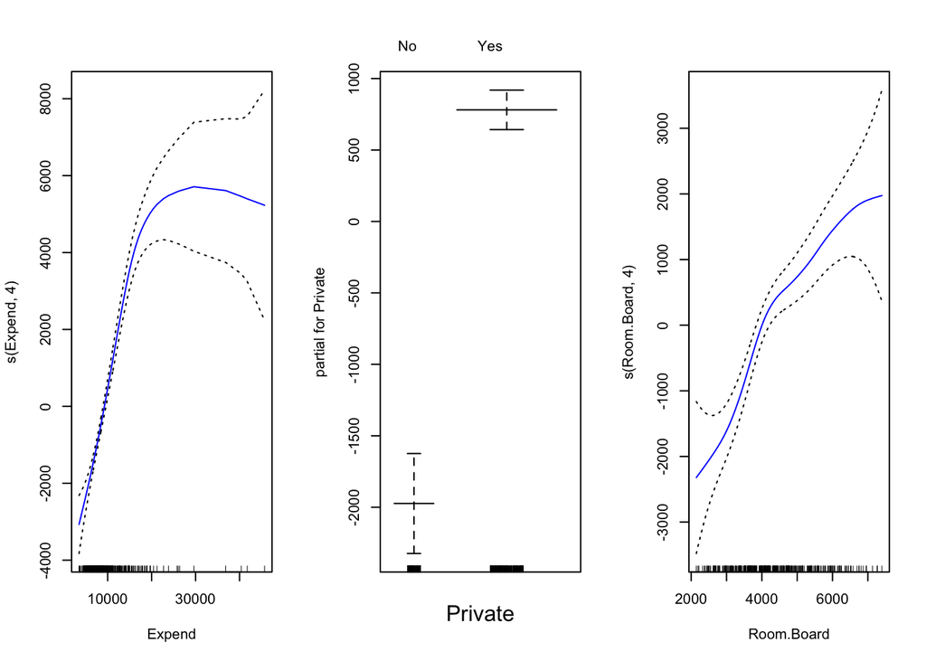

```r
par(mfrow=c(1,3))
plot(gam.fit, se=T, col='blue')
```

3. Evaluate on the test set.

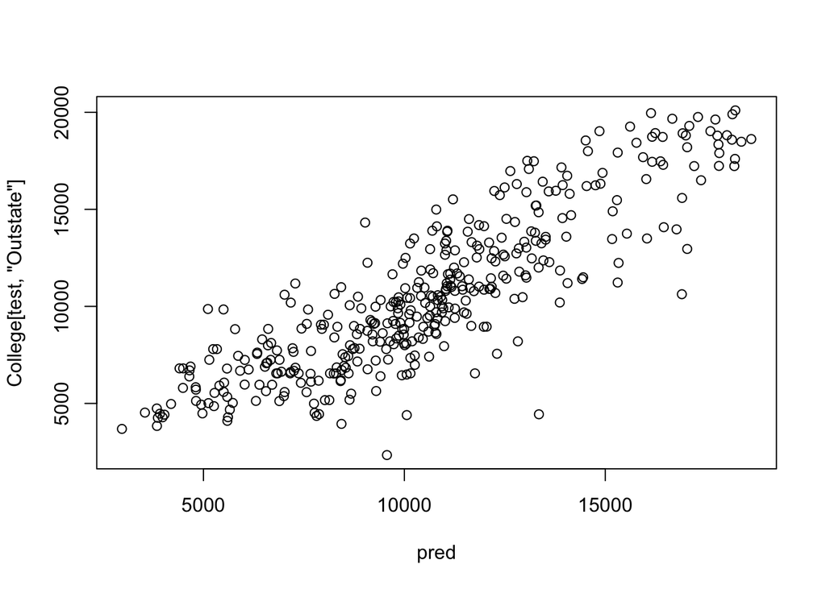

```r
pred = predict(gam.fit, newdata=College[test,])
par(mfrow=c(1,1))
plot(pred, College[test, 'Outstate'])
```

```r
rss = mean((pred - College[test, 'Outstate'])^2)
rss
```

```
## [1] 4157367
```

4. The summary from `gam` fit shows that there is evidence for non-linear relationship for both `Expend` and `Room.Board` variables.

## Question 11

1. Generate response

```r
set.seed(1)
x1 = rnorm(100)
x2 = rnorm(100)
y = .5 + 1*x1 + 1.5*x2 + rnorm(100)
#y = .5 + 1*ns(x1, df=4) + 1.5*ns(x2, df=4) + rnorm(100)
```

2. Assume $\beta_1 = 0$.

```r
b1 = 0
a = y - b1*x1
fit = lm(a~x2)
b2 = fit$coef[2]
b0 = fit$coef[1]
```

3. Do the same thing for $\beta_1$. Seems like only one iteration is enough.

```r
a = y - b2*x2
fit = lm(a~x1)
b1 = fit$coef[2]
b0 = fit$coef[1]
```

4. Do these in a loop.

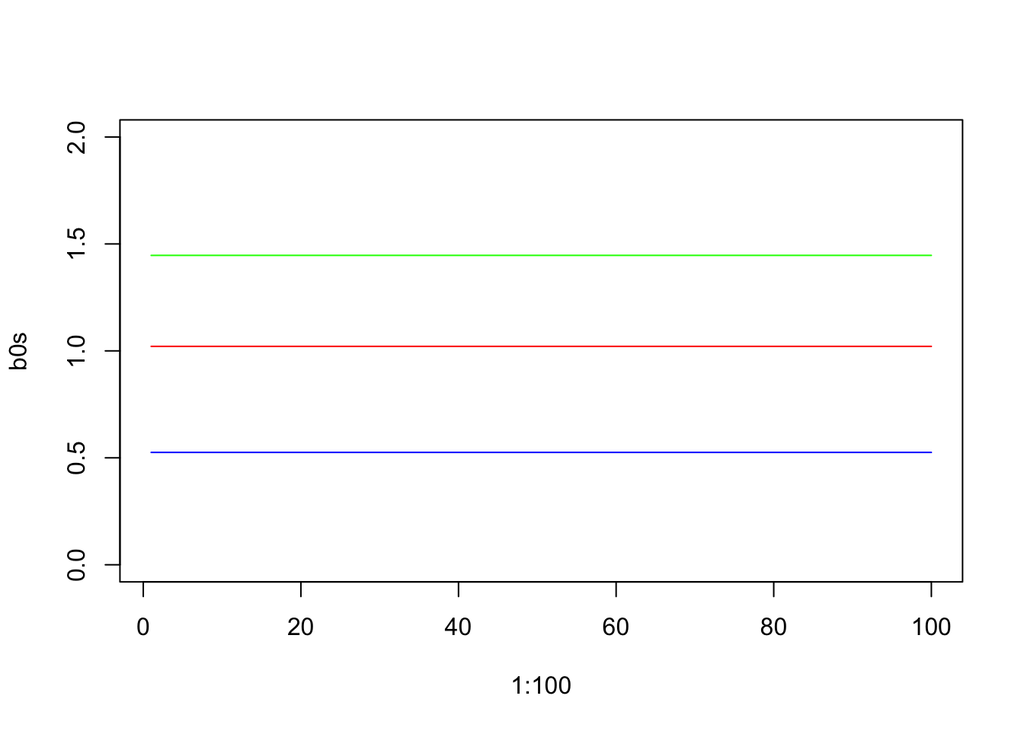

```r
b0s = rep(NA, 100)
b1s = rep(NA, 100)
b2s = rep(NA, 100)
b1 = rnorm(1)
for( i in 1:100 ){
  a = y - b1*x1
  fit = lm(a~x2)
  b2 = fit$coef[2]
  b0 = fit$coef[1]
  a = y - b2*x2
  fit = lm(a~x1)
  b1 = fit$coef[2]
  b0 = fit$coef[1]
  b0s[i] = b0
  b1s[i] = b1
  b2s[i] = b2
}
plot(1:100, b0s, col='blue', type='l', ylim=c(0,2))
lines(1:100, b1s, col='red')
lines(1:100, b2s, col='green')
```

5. Apply linear regression.

```r
lm.fit = lm(y~x1+x2, data=data.frame(x1=x1, x2=x2, y=y))
summary(lm.fit)
```

```
##
## Call:
## lm(formula = y ~ x1 + x2, data = data.frame(x1 = x1, x2 = x2,
##     y = y))
##
## Residuals:
##    Min     1Q Median     3Q    Max
## -2.944 -0.436  0.002  0.637  2.639
##
## Coefficients:
##             Estimate Std. Error t value Pr(>|t|)
## (Intercept)    0.525      0.105    4.99  2.6e-06 ***
## x1             1.021      0.117    8.75  6.8e-14 ***
## x2             1.447      0.109   13.21  < 2e-16 ***
## ---
## Signif. codes:  0 '***' 0.001 '**' 0.01 '*' 0.05 '.' 0.1 ' ' 1
##
## Residual standard error: 1.04 on 97 degrees of freedom
## Multiple R-squared:  0.721,  Adjusted R-squared:  0.715
## F-statistic:  125 on 2 and 97 DF,  p-value: <2e-16
```

```r
lm.fit$coef
```

```
## (Intercept)          x1          x2
##      0.5254      1.0211      1.4465
```

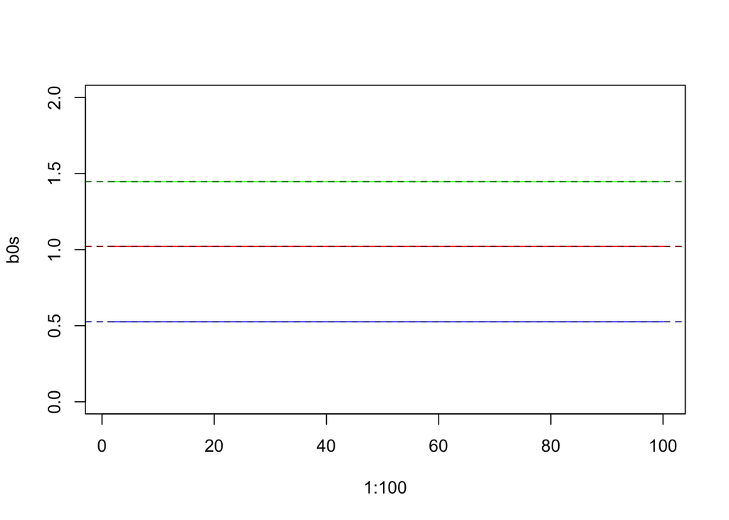

```r
plot(1:100, b0s, col='blue', type='l', ylim=c(0,2))
lines(1:100, b1s, col='red')
lines(1:100, b2s, col='green')
abline(h = lm.fit$coef[1], col='darkblue', lty='dashed')
abline(h = lm.fit$coef[2], col='darkred', lty='dashed')
abline(h = lm.fit$coef[3], col='darkgreen', lty='dashed')
```

7. We needed only one iteration to converge!!!